# ALDER

2025-02-03

```r
res_dir <- "../results/s07_ALDER/"
```

# Load gt

```r
mad_bor_g1000_sum_neo <-
  gt_load("../data/intermediate/rbind_data/rbind_sort_dist/mad_bor_g1000_sum_neo_clean.gt")
```

# Loci and sample count

```r
nrow(mad_bor_g1000_sum_neo)
```

```
## [1] 2697
```

```r
count_loci(mad_bor_g1000_sum_neo)
```

```
## [1] 215557
```

# Make $population a copy of $id

```r
mad_bor_g1000_sum_neo$population <- mad_bor_g1000_sum_neo$id
mad_bor_g1000_sum_neo <- mad_bor_g1000_sum_neo %>% group_by(population)
```

# Check the original gt

```r
is_loci_table_ordered(mad_bor_g1000_sum_neo,
  error_on_false = TRUE,
  ignore_genetic_dist = FALSE
)
```

```
## [1] TRUE
```

# Remove existing plink .bed files and write .bed

```r
if (file.exists("../data/intermediate/rbind_data/rbind_sort_dist/mad_bor_g1000_sum_neo.bed")) {
  file.remove("../data/intermediate/rbind_data/rbind_sort_dist/mad_bor_g1000_sum_neo.bed")
  file.remove("../data/intermediate/rbind_data/rbind_sort_dist/mad_bor_g1000_sum_neo.bim")
  file.remove("../data/intermediate/rbind_data/rbind_sort_dist/mad_bor_g1000_sum_neo.fam")
}
```

```
## [1] TRUE
```

```r
gt_as_plink(mad_bor_g1000_sum_neo, "../data/intermediate/rbind_data/rbind_sort_dist/mad_bor_g1000_sum_neo")
```

```
## [1] "../data/intermediate/rbind_data/rbind_sort_dist/mad_bor_g1000_sum_neo.bed"
```

# Transform to .ped

```bash
plink --bfile ../data/intermediate/rbind_data/rbind_sort_dist/mad_bor_g1000_sum_neo --recode --out ../data/intermediate/rbind_data/rbind_sort_dist/mad_bor_g1000_sum_neo
```

[output not shown]

# Read the plink file and set 6th col to 1

check and remove any snps without a map position

```r
mad_bor_g1000_sum_neo_fam <-
  read.table("../data/intermediate/rbind_data/rbind_sort_dist/mad_bor_g1000_sum_neo.fam",
    header = FALSE, sep = ""
  )

# colnames of $V1 to "id"
colnames(mad_bor_g1000_sum_neo_fam)[1] <- "id"
# colnames of $V6 to "population"
colnames(mad_bor_g1000_sum_neo_fam)[6] <- "population"

pop_table <- read.table("../data/raw/data_input/Madagascar_Borneo.poptable",
  sep = "\t", fill = TRUE
)
colnames(pop_table) <- c("IID", "V2", "FID", "Population", "V5", "V6", "V7")

# Remove the "RR"
mad_bor_g1000_sum_neo_fam$id <- sub("RR.*", "", mad_bor_g1000_sum_neo_fam$id)
mad_bor_g1000_sum_neo_fam$V2 <- sub("RR.*", "", mad_bor_g1000_sum_neo_fam$V2)

# Find Malagasy entries
pop_table_sub <- subset(pop_table, pop_table$IID %in% mad_bor_g1000_sum_neo_fam$id)

# match up the ID's with pop table metadata
matching_m <- match(mad_bor_g1000_sum_neo_fam$id, pop_table_sub$IID)

mad_bor_g1000_sum_neo_fam$population <- ifelse(!is.na(matching_m),
  pop_table_sub$Population[matching_m],
  mad_bor_g1000_sum_neo_fam$population
)


# replace any " " in $populaiton with a "_"
mad_bor_g1000_sum_neo_fam$population <- gsub(
  " ", "_",
  mad_bor_g1000_sum_neo_fam$population
)

# any $id begining GRC has $population "Sumba"
mad_bor_g1000_sum_neo_fam$population[grepl("^GRC", mad_bor_g1000_sum_neo_fam$id)] <- "Sumba"

# Load fastmixture results
mad_bor_g1000_sum_neo <-
  gt_load("../data/intermediate/rbind_data/mad_bor_g1000_sum_neo_clean.gt")
qmats <-
  readRDS("~/Dropbox/gitdata/malagasy_diversity/data/intermediate/fastmixture/fastmixture_m.RData")
# tidy with the gt
mad_bor_g1000_sum_neo <- augment(get_q_matrix(qmats, k = 3, run = 1),
  data = mad_bor_g1000_sum_neo
)
# filter to merina
merina <- mad_bor_g1000_sum_neo %>% filter(population == "Merina")
# split groups
# .Q3 representing Asian ancestry and .Q2 representing African ancestry
merina$population <- ifelse(merina$.Q3 > 0.5, "MerinaA", "MerinaB")
merina <- merina[, c("id", "population")]
merina$id <- sub("RR.*", "", merina$id)

# match V2 and merina$id and replace the population column in merina_fam with
# the population column in merina
matching_m <- match(mad_bor_g1000_sum_neo_fam$id, merina$id)
mad_bor_g1000_sum_neo_fam$population <- ifelse(!is.na(matching_m),
  merina$population[matching_m], mad_bor_g1000_sum_neo_fam$population
)

# mad_bor_g1000_sum_neo_fam$id <- as.numeric(rownames(mad_bor_g1000_sum_neo_fam))
mad_bor_g1000_sum_neo_fam$population <- as.factor(mad_bor_g1000_sum_neo_fam$population)

# mad_bor_g1000_sum_neo_fam$V6 <- mad_bor_g1000_sum_neo_fam$population
write.table(mad_bor_g1000_sum_neo_fam,
  "../data/intermediate/rbind_data/rbind_sort_dist/mad_bor_g1000_sum_neo.fam",
  row.names = FALSE, col.names = FALSE, sep = " ", quote = FALSE
)
```

```r
if (file.exists("../data/intermediate/rbind_data/rbind_sort_dist/mad_bor_g1000_sum_neo.geno")) {
  file.remove("../data/intermediate/rbind_data/rbind_sort_dist/mad_bor_g1000_sum_neo.geno")
  file.remove("../data/intermediate/rbind_data/rbind_sort_dist/mad_bor_g1000_sum_neo.ind")
  file.remove("../data/intermediate/rbind_data/rbind_sort_dist/mad_bor_g1000_sum_neo.snp")
}
```

# Write a bash scripts to convert plink to eigenstrat

# Run script

```bash
cd ~/Git/malagasy_diversity/code
convertf -p s11a_convertf.par
```

[output not shown]

# Population to Status column as described here

https://reich.hms.harvard.edu/software/InputFileFormats

# Write a test bash script for ALDER

mindis: 0.005 - minimum genetic distance (in Morgans) at which to start curve fitting (default: determined using LD correlation). https://comppopgenworkshop2019.readthedocs.io/en/latest/contents/06_alder/alder.html States that the default calculates the correlation in LD decay between the target and each reference, and uses ‘the minimum distance that shows no correlation in both references.’ ‘If it continues beyond 2 cM (due to either a strong bottleneck or admixture in a reference), the program aborts.’ In example with Merina as Target and Esan and Borneo as reference, setting mindis to default causes the program to abort. What does mindis do to the results?

jackknife: YES - outputs results from leave-one-chromosome-out jackknifing

For now, using checkmap: NO - why does our map have an issue?

binsize: 0.0005 default - genetic distance resolution (in Morgans) - the size of bins that ALDER splits the genome up into, used to calculate the distance between the bins of two snps as opposed to the distance between the each individual pair of snps, for computational efficiency

# Run bash scripts

```bash
cd ~/Git/malagasy_diversity/code
alder -p s07b_alder_merina_a.par > s07b_alder_merina_a.log
alder -p s07b_alder_merina_b.par > s07b_alder_merina_b.log
alder -p s07b_alder_mikea.par > s07b_alder_mikea.log
alder -p s07b_alder_vezo.par > s07b_alder_vezo.log
alder -p s07b_alder_temoro.par > s07b_alder_temoro.log
alder -p s07b_alder_betsileo.par > s07b_alder_betsileo.log
alder -p s07b_alder_betsimisaraka.par > s07b_alder_betsimisaraka.log
alder -p s07b_alder_diego.par > s07b_alder_diego.log
alder -p s07b_alder_sakalava_tsimihety.par > s07b_alder_sakalava_tsimihety.log
```

# Boxplot

```r
files <- list.files("../code",
  pattern = ".log",
  full.names = TRUE
)

# remove any from files that don't have 'alder' in  the name
files <- files[grepl("_alder", files)]

# use readLines to read each of files
logs <- lapply(files, readLines)

# Extract "DATA:" lines from each log file in the list
data_lines <- lapply(
  logs,
  function(log_file) {
    log_file[grepl("^DATA:",
      log_file,
      ignore.case = TRUE
    )]
  }
)


# Extract the first line from each element in data_lines
first_lines <- sapply(data_lines, function(x) if (length(x) > 0) x[1] else NA)

# Split each first "DATA:" line by backslash "\\"
split_data <- lapply(first_lines, function(x) strsplit(x, "\t")[[1]])

result <- do.call(rbind, split_data)
result <- as.data.frame(result, stringsAsFactors = FALSE)
# remove NA row
result <- result[complete.cases(result), ]
```

```r
# Extract the second line from each element in data_lines
second_lines <- sapply(data_lines, function(x) if (length(x) > 0) x[2] else NA)

# split second lines by "\"
split_data2 <- lapply(second_lines, function(x) strsplit(x, "\t")[[1]])
# apply colnames
colnames(result) <- split_data2[[1]]
# remove first two columns
result <- result[, -c(1, 2)]

# split $`2-ref decay` into 2 columns
split_dates <- do.call(rbind, strsplit(result$`2-ref decay`, " "))
# remove the middle column
split_dates <- split_dates[, -2]
# add column names
colnames(split_dates) <- c("admixture_date", "CI")
# turn into a dataframe
split_dates <- as.data.frame(split_dates)
# make numeric
split_dates$admixture_date <- as.numeric(split_dates$admixture_date)
split_dates$CI <- as.numeric(split_dates$CI)
result <- cbind(result, split_dates)

# split $`2-ref amp_exp` into 2 columns
split_amp <- do.call(rbind, strsplit(result$`2-ref amp_exp`, " "))
# remove the middle column
split_amp <- split_amp[, -2]
# add column names
colnames(split_amp) <- c("amp_exp", "amp_exp_CI")
# turn into a dataframe
split_amp <- as.data.frame(split_amp)
# make numeric
split_amp$amp_exp <- as.numeric(split_amp$amp_exp)
split_amp$amp_exp_CI <- as.numeric(split_amp$amp_exp_CI)
result <- cbind(result, split_amp)
print(result)
```

```
##     p-value           test pop  ref A ref B 2-ref z-score 1-ref z-score A
## 1  3.3e-245           Betsileo Borneo  Esan         33.44           27.94
## 2  2.9e-163      Betsimisaraka Borneo  Esan         27.23           24.10
## 3  3.3e-157              Diego Borneo  Esan         26.71           26.41
## 4   6.3e-99            MerinaA Borneo  Esan         21.11           13.29
## 5   2.5e-68            MerinaB Borneo  Esan         17.47           17.44
## 6  1.2e-159             Merina Borneo  Esan         26.92           15.52
## 7   6.1e-50              Mikea Borneo  Esan         14.86           14.45
## 8  1.2e-101 Sakalava_Tsimihety Borneo  Esan         21.41           21.16
## 9  1.5e-172             Temoro Borneo  Esan         28.00           24.76
## 10  7.6e-63               Vezo Borneo  Esan         16.73           14.39
##    1-ref z-score B max decay diff %    2-ref decay             2-ref amp_exp
## 1            30.83               3% 25.59 +/- 0.77 0.00124490 +/- 0.00002943
## 2            24.88               5% 28.65 +/- 1.05 0.00108739 +/- 0.00002585
## 3            19.86               6% 20.23 +/- 0.76 0.00084726 +/- 0.00002928
```

[output cut: 29 more lines]

```r
rownames(result) <- result$`test pop`
```

```r
# Process each log file
amp_aff_lines <- lapply(logs, function(log_text) {
  # Find the index of the header
  header_index <- grep("Computing 2-ref weighted LD with weights...", log_text)

  if (length(header_index) == 0) {
    return(NA) # Return NA if the header is not found
  }

  # Search for 'amp_aff:' after the header
  amp_aff_index <- grep("amp_aff:",
                        log_text[(header_index + 1):length(log_text)])

  if (length(amp_aff_index) == 0) {
    return(NA) # Return NA if no 'amp_aff:' line is found
  }

  # Extract the first matching line
  log_text[header_index + amp_aff_index[1]]
})

amp_aff_lines <- do.call(rbind, amp_aff_lines)
amp_aff_lines <- amp_aff_lines[complete.cases(amp_aff_lines), ]
amp_aff_lines <- do.call(rbind, strsplit(amp_aff_lines, " "))
result$amp_aff <- as.numeric(amp_aff_lines[, 8])

result$`test pop` <- factor(result$`test pop`,
                            levels = c("Betsimisaraka", "Temoro", "MerinaB",
                                       "Betsileo", "Mikea", "Merina",
                                       "Sakalava_Tsimihety", "Vezo", "MerinaA",
                                       "Diego"))
```

```r
# save result
saveRDS(result, "../results/s07_ALDER/alder_results.RData")
```

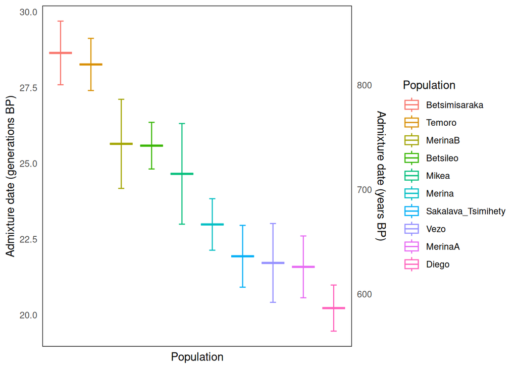

```r
ggplot(result, aes(x = `test pop`, y = admixture_date, colour = `test pop`)) +
  geom_boxplot() +
  scale_y_continuous(
    "Admixture date (generations BP)",
    sec.axis = sec_axis(~ . * 29, name = "Admixture date (years BP)")
  ) +
  geom_errorbar(aes(ymin = admixture_date - CI,
                    ymax = admixture_date + CI),
                width = 0.2) +
  labs(x = "Population", y = "Admixture date (generations BP)",
       colour = "Population") +
  theme_minimal() +
  theme(
    axis.text.x = element_blank(),
    legend.position = "right",
    axis.line = element_blank(),
    panel.grid.major = element_blank(),
    panel.grid.minor = element_blank(),
    panel.background = element_rect(fill = "white")
  )
```

```r
ggsave(paste0(res_dir, "alder_results.jpg"), width = 7, height = 5, dpi = 300)
```

# Example plot

‘Weighted LD curves computed on real populations often exhibit a nonzero horizontal asymptote contrary to the exact exponential decay formulas we have derived above. Such behavior can be caused by assortative mating resulting in subpopulations structured by ancestry percentage in violation of our model. We show in Appendix A that if we instead model the admixed population as consisting of randomly mating subpopulations with heterogeneous amounts α—now a random variable—of mixed ancestry, our equations for the curves take the form’

$$E[a(d)] = M e^{-nd} + K$$

‘We fit discretized weighted LD curves as from Equation 9, using least-squares to find best-fit parameters.’ (Loh et al 2014)

Using plot code from https://comppopgenworkshop2019.readthedocs.io/en/latest/contents/06_alder/alder.html Which describes as: E[Y] = M times e^-nd + K

```r
fn1 <- "../results/s07_ALDER/alder_merina.txt"

n <- result["Merina", ]$admixture_date ## decay - estimated admixture date
M <- result["Merina", ]$amp_exp ## amp_exp -
K <- result["Merina", ]$amp_aff ## amp_aff -

d1 <- read.table(fn1, header = FALSE)
d1 <- d1[-nrow(d1), ]
colnames(d1) <- c("Dist", "weightedLD", "npairs")
xv <- as.vector(d1$Dist) ## distance between SNP bins (cM) - genetic distance
yv <- as.vector(d1$weightedLD) ## Weighted LD

prdv <- M * exp(-1 * n * xv / 100) + K # E[Y] = M times e^-nd + K

dev.new()
plot(xv, yv, xlab = "Genetic distance (cM)", ylab = "weighted LD",
     main = "Merina", pch = 4, col = "blue")
points(xv, prdv, type = "l", lwd = 1.5, col = "red")
```

```r
fn1 <- "../results/s07_ALDER/alder_merina_a.txt"

n <- result["MerinaA", ]$admixture_date ## decay - estimated admixture date
M <- result["MerinaA", ]$amp_exp ## amp_exp -
K <- result["MerinaA", ]$amp_aff ## amp_aff -

d1 <- read.table(fn1, header = FALSE)
d1 <- d1[-nrow(d1), ]
colnames(d1) <- c("Dist", "weightedLD", "npairs")
xv <- as.vector(d1$Dist) ## distance between SNP bins (cM)
yv <- as.vector(d1$weightedLD) ## Weighted LD

prdv <- M * exp(-1 * n * xv / 100) + K # E[Y] = M times e^-nd + K

dev.new()
plot(xv, yv, xlab = "Genetic distance (cM)", ylab = "weighted LD",
     main = "Merina A", pch = 4, col = "blue")
points(xv, prdv, type = "l", lwd = 1.5, col = "red")
```

```r
fn1 <- "../results/s07_ALDER/alder_merina_b.txt"

n <- result["MerinaB", ]$admixture_date ## decay - estimated admixture date
M <- result["MerinaB", ]$amp_exp ## amp_exp -
K <- result["MerinaB", ]$amp_aff ## amp_aff -

d1 <- read.table(fn1, header = FALSE)
d1 <- d1[-nrow(d1), ]
colnames(d1) <- c("Dist", "weightedLD", "npairs")
xv <- as.vector(d1$Dist) ## distance between SNP bins (cM)
yv <- as.vector(d1$weightedLD) ## Weighted LD

prdv <- M * exp(-1 * n * xv / 100) + K # E[Y] = M times e^-nd + K

dev.new()
plot(xv, yv, xlab = "Genetic distance (cM)", ylab = "weighted LD",
     main = "Merina B", pch = 4, col = "blue")
points(xv, prdv, type = "l", lwd = 1.5, col = "red")
```

```r
fn1 <- "../results/s07_ALDER/alder_mikea.txt"

n <- result["Mikea", ]$admixture_date ## decay - estimated admixture date
M <- result["Mikea", ]$amp_exp ## amp_exp -
K <- result["Mikea", ]$amp_aff ## amp_aff -

d1 <- read.table(fn1, header = FALSE)
d1 <- d1[-nrow(d1), ]
colnames(d1) <- c("Dist", "weightedLD", "npairs")
xv <- as.vector(d1$Dist) ## distance between SNP bins (cM)
yv <- as.vector(d1$weightedLD) ## Weighted LD

prdv <- M * exp(-1 * n * xv / 100) + K # E[Y] = M times e^-nd + K

dev.new()
plot(xv, yv, xlab = "Genetic distance (cM)", ylab = "weighted LD",
     main = "Mikea", pch = 4, col = "blue")
points(xv, prdv, type = "l", lwd = 1.5, col = "red")
```

```r
fn1 <- "../results/s07_ALDER/alder_vezo.txt"

n <- result["Vezo", ]$admixture_date ## decay - estimated admixture date
M <- result["Vezo", ]$amp_exp ## amp_exp -
K <- result["Vezo", ]$amp_aff ## amp_aff -

d1 <- read.table(fn1, header = FALSE)
d1 <- d1[-nrow(d1), ]
colnames(d1) <- c("Dist", "weightedLD", "npairs")
xv <- as.vector(d1$Dist) ## distance between SNP bins (cM)
yv <- as.vector(d1$weightedLD) ## Weighted LD

prdv <- M * exp(-1 * n * xv / 100) + K # E[Y] = M times e^-nd + K

dev.new()
plot(xv, yv, xlab = "Genetic distance (cM)", ylab = "weighted LD",
     main = "Vezo", pch = 4, col = "blue")
points(xv, prdv, type = "l", lwd = 1.5, col = "red")
```

```r
fn1 <- "../results/s07_ALDER/alder_temoro.txt"

n <- result["Temoro", ]$admixture_date ## decay - estimated admixture date
M <- result["Temoro", ]$amp_exp ## amp_exp -
K <- result["Temoro", ]$amp_aff ## amp_aff -

d1 <- read.table(fn1, header = FALSE)
d1 <- d1[-nrow(d1), ]
colnames(d1) <- c("Dist", "weightedLD", "npairs")
xv <- as.vector(d1$Dist) ## distance between SNP bins (cM)
yv <- as.vector(d1$weightedLD) ## Weighted LD

prdv <- M * exp(-1 * n * xv / 100) + K # E[Y] = M times e^-nd + K

dev.new()
plot(xv, yv, xlab = "Genetic distance (cM)", ylab = "weighted LD",
     main = "Temoro", pch = 4, col = "blue")
points(xv, prdv, type = "l", lwd = 1.5, col = "red")
```

```r
fn1 <- "../results/s07_ALDER/alder_betsileo.txt"

n <- result["Betsileo", ]$admixture_date ## decay - estimated admixture date
M <- result["Betsileo", ]$amp_exp ## amp_exp -
K <- result["Betsileo", ]$amp_aff ## amp_aff -

d1 <- read.table(fn1, header = FALSE)
d1 <- d1[-nrow(d1), ]
colnames(d1) <- c("Dist", "weightedLD", "npairs")
xv <- as.vector(d1$Dist) ## distance between SNP bins (cM)
yv <- as.vector(d1$weightedLD) ## Weighted LD

prdv <- M * exp(-1 * n * xv / 100) + K # E[Y] = M times e^-nd + K

dev.new()
plot(xv, yv, xlab = "Genetic distance (cM)", ylab = "weighted LD",
     main = "Betsileo", pch = 4, col = "blue")
points(xv, prdv, type = "l", lwd = 1.5, col = "red")
```

```r
fn1 <- "../results/s07_ALDER/alder_betsimisaraka.txt"

n <- result["Betsimisaraka", ]$admixture_date ## decay - estimated admixture date
M <- result["Betsimisaraka", ]$amp_exp ## amp_exp -
K <- result["Betsimisaraka", ]$amp_aff ## amp_aff -

d1 <- read.table(fn1, header = FALSE)
d1 <- d1[-nrow(d1), ]
colnames(d1) <- c("Dist", "weightedLD", "npairs")
xv <- as.vector(d1$Dist) ## distance between SNP bins (cM)
yv <- as.vector(d1$weightedLD) ## Weighted LD

prdv <- M * exp(-1 * n * xv / 100) + K # E[Y] = M times e^-nd + K

dev.new()
plot(xv, yv, xlab = "Genetic distance (cM)", ylab = "weighted LD",
     main = "Betsimisaraka", pch = 4, col = "blue")
points(xv, prdv, type = "l", lwd = 1.5, col = "red")
```

```r
fn1 <- "../results/s07_ALDER/alder_diego.txt"

n <- result["Diego", ]$admixture_date ## decay - estimated admixture date
M <- result["Diego", ]$amp_exp ## amp_exp -
K <- result["Diego", ]$amp_aff ## amp_aff -

d1 <- read.table(fn1, header = FALSE)
d1 <- d1[-nrow(d1), ]
colnames(d1) <- c("Dist", "weightedLD", "npairs")
xv <- as.vector(d1$Dist) ## distance between SNP bins (cM)
yv <- as.vector(d1$weightedLD) ## Weighted LD

prdv <- M * exp(-1 * n * xv / 100) + K # E[Y] = M times e^-nd + K

dev.new()
plot(xv, yv, xlab = "Genetic distance (cM)", ylab = "weighted LD",
     main = "Diego", pch = 4, col = "blue")
points(xv, prdv, type = "l", lwd = 1.5, col = "red")
```

```r
fn1 <- "../results/s07_ALDER/alder_sakalava_tsimihety.txt"

n <- result["Sakalava_Tsimihety", ]$admixture_date ## decay - estimated admixture date
M <- result["Sakalava_Tsimihety", ]$amp_exp ## amp_exp -
K <- result["Sakalava_Tsimihety", ]$amp_aff ## amp_aff -

d1 <- read.table(fn1, header = FALSE)
d1 <- d1[-nrow(d1), ]
colnames(d1) <- c("Dist", "weightedLD", "npairs")
xv <- as.vector(d1$Dist) ## distance between SNP bins (cM)
yv <- as.vector(d1$weightedLD) ## Weighted LD

prdv <- M * exp(-1 * n * xv / 100) + K # E[Y] = M times e^-nd + K

dev.new()
plot(xv, yv, xlab = "Genetic distance (cM)", ylab = "weighted LD",
     main = "Sakalava_Tsimihety", pch = 4, col = "blue")
points(xv, prdv, type = "l", lwd = 1.5, col = "red")
```

## Recording R environment

Part of ensuring our workflow is reproducible is to keep track of the R environment. We will automatically save our R environment into a file called `r_environment.json`.